# EP02-respuesta-equipo-2

Andre Cosio-Jazmin Melo-Benjamín Valenzuela

2025-03-25

# Importación de Packages.

```r
if (!require("ggpubr")) install.packages("ggpubr")
if (!require("dplyr")) install.packages("dplyr")
```

```r
if (!require("ggplot2")) install.packages("ggplot2", dependencies = TRUE)
if (!require("gridExtra")) install.packages("gridExtra")
if (!require("tidyr")) install.packages("tidyr")
library(tidyr)
library(dplyr)
library(ggplot2)
library(gridExtra)
if (!require("ggpubr")) install.packages("ggpubr")
library(ggpubr)

if (!require(dplyr)){
  install.packages("dplyr", dependencies=TRUE)
  require (dplyr)}
```

# Pregunta 1: El Comité Olímpico cree que el mejor tiempo medio de los atletas de raza oriental antes de ingresar al programa de entrenamiento era inferior a 19,8 segundos. ¿Soportan los datos esta afirmación?

```r
# LECTURA DE DOCUMENTO:
datos2 <- read.csv2(file.choose())

# FILTRO DE ATLETAS ORIENTALES:
atletas_orientales <- datos2 |> filter(Raza == "Oriental")
```

Comencemos verificando las hipótesis que son posibles de formular:

- H0: Tiempo medio de los atletas de raza oriental antes de ingresar al programa de entrenamiento es igual a 19.8 segundos.
- HA: Tiempo medio de los atletas de raza oriental antes de ingresar al programa de entrenamiento es menor a 19.8 segundos.

Para saber que tipo de prueba es necesario verificar que condiciones se presentan en el problema:

```r
# NÚMERO DE ATLETAS ORIENTALES
n_atletas <- nrow(datos2)

cat("CANTIDAD DE ATLETAS TOTALES = ", n_atletas, "\n")
```

```
## CANTIDAD DE ATLETAS TOTALES =  81
```

```r
# NÚMERO DE ATLETAS ORIENTALES
n_atletas_o <- nrow(atletas_orientales)

cat("CANTIDAD DE ATLETAS ORIENTALES = ", n_atletas_o, "\n")
```

```
## CANTIDAD DE ATLETAS ORIENTALES =  27
```

```r
porcentaje <- (n_atletas_o*100)/n_atletas

cat("PORCENTAJE DE ATLETAS ORIENTALES = ", porcentaje, "%")
```

```
## PORCENTAJE DE ATLETAS ORIENTALES =  33.33333 %
```

- Podemos ver que dentro del gráfico Q-Q,los datos poseen un comportamiento esperado a una distribución normal, puesto a que no se alejan mucho el uno de al otro.

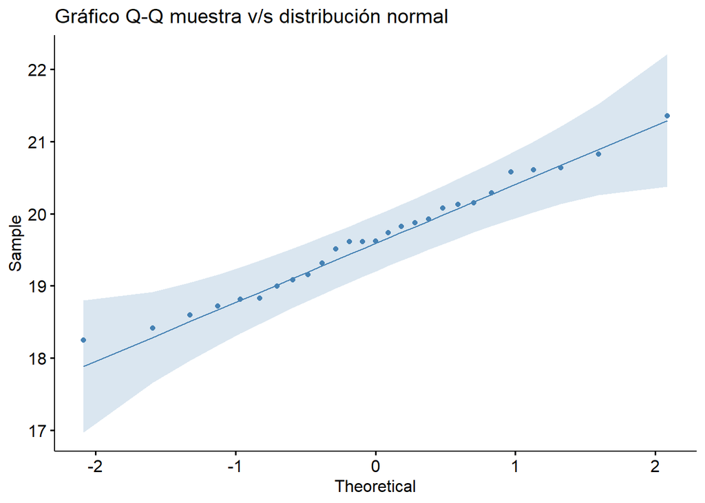

```r
q_q <- ggqqplot(atletas_orientales, x = "Previo", color = "steelblue", title = "Gráfico Q-Q muestra v/s distribución normal")
print(q_q)
```

- Podemos ver que la cantidad de observaciones de ATLETAS ORIENTALES es 27, un valor menor a 30 y no es presentado un valor de “desviación estándar de la población”.

```r
cat("CANTIDAD DE ATLETAS ORIENTALES = ", n_atletas_o)
```

```
## CANTIDAD DE ATLETAS ORIENTALES =  27
```

- De igual forma, ni el enunciado ni la tabla de información presenta un valor que represente la desviación estándar de la población, es por lo anteriormente mencionado que el problema no es posible de solucionar por medio de la Prueba-Z, pero si lo es por medio de la Prueba-T-Studient para una sola muestra.

```r
alfa <- 0.05 # 95% de significación

grados_livertad <- n_atletas_o - 1

tabla_pervios_o <- atletas_orientales |> select(Previo)

media <- mean(tabla_pervios_o$Previo)
desv_est <- sd(tabla_pervios_o$Previo)
error_est <- desv_est/sqrt(n_atletas_o)

t <- (media - 19.8)/error_est

valor_p <- pt(t, df = grados_livertad, lower.tail = TRUE)

t_crit <- qt(alfa, df = grados_livertad, lower.tail = FALSE)
#---------------------------------------------------------------------------------------

resultado2 <- t.test(tabla_pervios_o$Previo, mu = 19.8, alternative = "less", conf.level = 1 - alfa)

print(resultado2)
```

```
##
##  One Sample t-test
##
## data:  tabla_pervios_o$Previo
## t = -0.98585, df = 26, p-value = 0.1666
## alternative hypothesis: true mean is less than 19.8
## 95 percent confidence interval:
##      -Inf 19.90965
## sample estimates:
## mean of x
##  19.64981
```

#Comparación, valor p contra alfa:

```r
if(resultado2$p.value > alfa){
  print(paste("El valor p =", resultado2$p.value, "es mayor que el valor propuesto de significación =", alfa))
}else{
  print(paste("El valor p =", resultado2$p.value, "es menor que el valor propuesto de significación =", alfa))
}
```

```
## [1] "El valor p = 0.166645709798949 es mayor que el valor propuesto de significación = 0.05"
```